# STAT 345 Midterm Project

Due March 29

Produce a graphic displaying the shot locations for a particular team over several years.

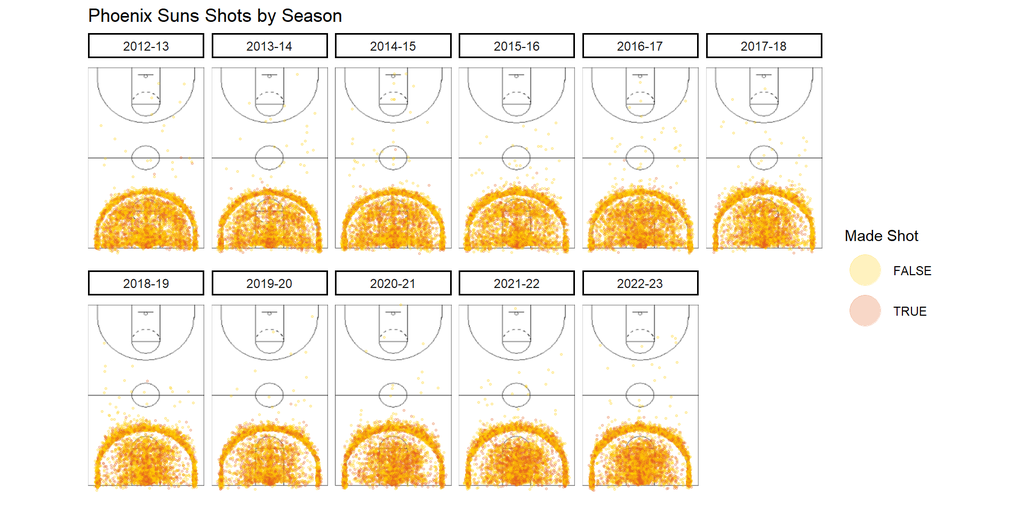

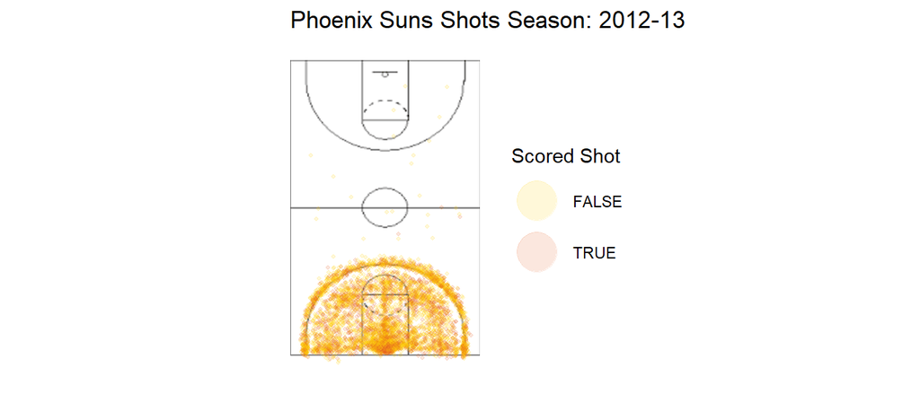

- Through the plots we can see an overall shift in shot distribution from season to season, where the distribution transitions from all throughout the area of the 3 point line to a clear distinction between 3 point line shots, and shots inside the “key”.

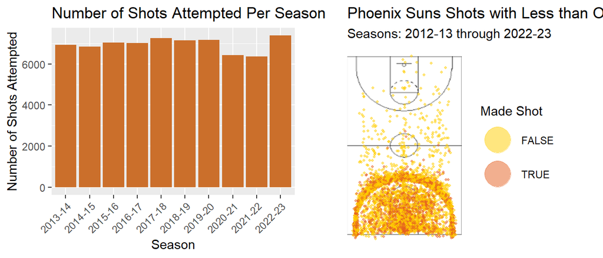

For the Phoenix Suns over the 2012-13 to 2022-23 seasons, shots are more spread throughout the inside of 3 point line arch in the earlier seasons, and there is a trend of less and less spread as seasons get more recent. Instead, there is a higher concentration of shots being taken at the 3 point line, or inside the “key”. By the 2022-23 season there seems to be a clear gap where shots are not being taken. This is most likely an intentional shift where players are focusing more on either attempting higher value shots, or getting closer to the hoop for better chances of making it in. Comparing 2012-23 to 2022-23, it is very clear that there is a difference in shot placement, and 2022-23 seems to have the highest contrast in with 2012-13 in terms of shot distribution.

Looking at the plot of shots attempted for all seasons when the game had less than 1 minute left, we can see a much higher proportion of shots being taken in the opponents side of the court compared to an overall shot distribution from any one season. From the plot we can see that almost all of the shots attempted past mid range and on opponents side of the court are missed shots, most likely last attempts to get a basket when there wasn’t enough time to move closer to the net.

How does contract compensation compare to player performance?

```
## You got Hoops Hype NBA Team Salary Data
```

```
## [1] "Kevin Durant 2023-2024 Contract Amount: $47,649,433"
```

```
## [1] "Thaddeus Young 2023-2024 Contract Amount: $1,010,371"
```

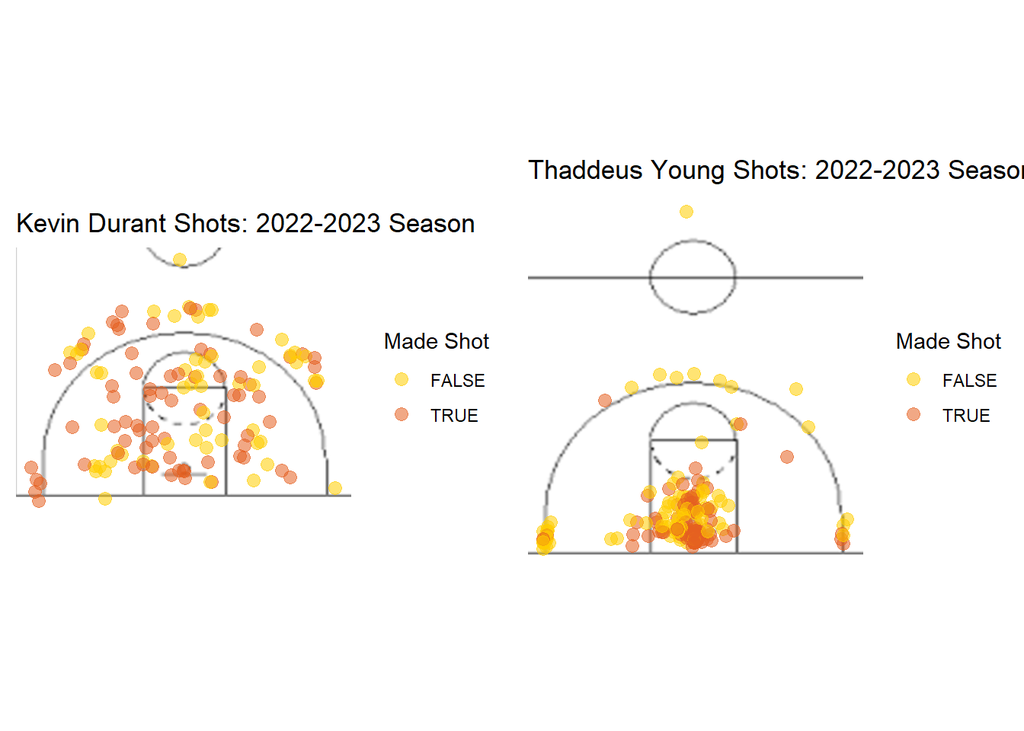

- Comparing shots for 2022-2023, Kevin Durant seems to be making more shots overall, all over the court. Young’s shots seem to be specific to the center 3 point line, far left and right 3 point line, and near the hoop. His most successful shots are close to the hoop, low scoring points.

[output not shown]

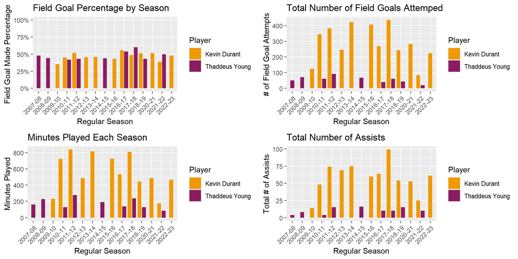

To go deeper, lets compare some basic statistics by referencing players_career() data. Unfortunately, this data contains missing information as seen in the graphics, but overall trends can still be seen.

- Durant and Young have similar percentages of field goals made
- Durant seems to be making far more attempts at field goals overall throughout his career compared to Young
- Durant plays far more minutes throughout his career compared to minutes played by Young
- Durant contributes to far more assists throughout his career as well

All of these figures can contribute to the large difference in contract compensation. Durant seems to be playing more, and scoring more compared to Young.